# Steps and tasks:

```
1. Import the necessary libraries
2. Read the data as a data frame
3. Perform basic EDA which should include the following and print out your insights at every step.
    a. Shape of the data
    b. Data type of each attribute
    c. Checking the presence of missing values
    d. 5 Point summary of numerical attributes
    e. Checking the presence of outliers
4. Prepare the data to train a model – check if data types are appropriate, get rid of the missing values etc.
5. Train a few standard classification algorithms, note and comment on their performances across different classification metrics.
6. Build the ensemble models and compare the results with the base models. Note: Random forest can be used only with Decision trees.
7. Compare performances of all the models
```

```python
%matplotlib inline
```

# 1. Import the necessary libraries

```python
import numpy as np
import pandas as pd
import matplotlib.pyplot as plt
import seaborn as sns
from sklearn import metrics # calculate accuracy measures and confusion matrix
from sklearn.model_selection import train_test_split
from sklearn.tree import DecisionTreeClassifier
from sklearn.linear_model import LogisticRegression
from sklearn.naive_bayes import GaussianNB
from sklearn.neighbors import KNeighborsClassifier
from sklearn.ensemble import RandomForestClassifier
from sklearn.ensemble import VotingClassifier
from sklearn.ensemble import BaggingClassifier
from sklearn.ensemble import AdaBoostClassifier
from sklearn.ensemble import GradientBoostingClassifier
from sklearn.feature_extraction.text import CountVectorizer  #DT does not take strings as input for the model fit step.
from IPython.display import Image
import pydotplus as pydot
from sklearn import tree
from os import system
import graphviz
```

# 2. Read the data as a data frame

```python
bank_df = pd.read_csv("bank-full.csv")
```

# 3. Perform basic EDA which should include the following and print out your insights at every step.

### a. Shape of the data

```python
bank_df.shape
```

```
(45211, 17)
```

### b. Data type of each attribute

```python
datatype=bank_df.dtypes
print(datatype)
```

```
age           int64
job          object
marital      object
education    object
default      object
balance       int64
housing      object
loan         object
contact      object
day           int64
month        object
duration      int64
campaign      int64
pdays         int64
previous      int64
poutcome     object
Target       object
dtype: object
```

```python
bank_df.info()
```

```
<class 'pandas.core.frame.DataFrame'>
RangeIndex: 45211 entries, 0 to 45210
Data columns (total 17 columns):
age          45211 non-null int64
job          45211 non-null object
marital      45211 non-null object
education    45211 non-null object
default      45211 non-null object
balance      45211 non-null int64
housing      45211 non-null object
loan         45211 non-null object
contact      45211 non-null object
day          45211 non-null int64
month        45211 non-null object
duration     45211 non-null int64
campaign     45211 non-null int64
pdays        45211 non-null int64
previous     45211 non-null int64
poutcome     45211 non-null object
Target       45211 non-null object
dtypes: int64(7), object(10)
memory usage: 5.9+ MB
```

### c. Checking the presence of missing values

```python
 bank_df.isnull().values.any()
```

```
False
```

```python
bank_df.head(10)
```

|  | age | job | marital | education | default | balance | housing | loan | contact | day | month | duration | campaign | pdays | previous | poutcome | Target |
| --- | --- | --- | --- | --- | --- | --- | --- | --- | --- | --- | --- | --- | --- | --- | --- | --- | --- |
| 0 | 58 | management | married | tertiary | no | 2143 | yes | no | unknown | 5 | may | 261 | 1 | -1 | 0 | unknown | no |
| 1 | 44 | technician | single | secondary | no | 29 | yes | no | unknown | 5 | may | 151 | 1 | -1 | 0 | unknown | no |
| 2 | 33 | entrepreneur | married | secondary | no | 2 | yes | yes | unknown | 5 | may | 76 | 1 | -1 | 0 | unknown | no |
| 3 | 47 | blue-collar | married | unknown | no | 1506 | yes | no | unknown | 5 | may | 92 | 1 | -1 | 0 | unknown | no |
| 4 | 33 | unknown | single | unknown | no | 1 | no | no | unknown | 5 | may | 198 | 1 | -1 | 0 | unknown | no |
| 5 | 35 | management | married | tertiary | no | 231 | yes | no | unknown | 5 | may | 139 | 1 | -1 | 0 | unknown | no |
| 6 | 28 | management | single | tertiary | no | 447 | yes | yes | unknown | 5 | may | 217 | 1 | -1 | 0 | unknown | no |
| 7 | 42 | entrepreneur | divorced | tertiary | yes | 2 | yes | no | unknown | 5 | may | 380 | 1 | -1 | 0 | unknown | no |
| 8 | 58 | retired | married | primary | no | 121 | yes | no | unknown | 5 | may | 50 | 1 | -1 | 0 | unknown | no |
| 9 | 43 | technician | single | secondary | no | 593 | yes | no | unknown | 5 | may | 55 | 1 | -1 | 0 | unknown | no |

### d. 5 Point summary of numerical attributes

```python
bank_df.describe(include=[np.number]).T
```

|  | count | mean | std | min | 25% | 50% | 75% | max |
| --- | --- | --- | --- | --- | --- | --- | --- | --- |
| age | 45211.0 | 40.936210 | 10.618762 | 18.0 | 33.0 | 39.0 | 48.0 | 95.0 |
| balance | 45211.0 | 1362.272058 | 3044.765829 | -8019.0 | 72.0 | 448.0 | 1428.0 | 102127.0 |
| day | 45211.0 | 15.806419 | 8.322476 | 1.0 | 8.0 | 16.0 | 21.0 | 31.0 |
| duration | 45211.0 | 258.163080 | 257.527812 | 0.0 | 103.0 | 180.0 | 319.0 | 4918.0 |
| campaign | 45211.0 | 2.763841 | 3.098021 | 1.0 | 1.0 | 2.0 | 3.0 | 63.0 |
| pdays | 45211.0 | 40.197828 | 100.128746 | -1.0 | -1.0 | -1.0 | -1.0 | 871.0 |
| previous | 45211.0 | 0.580323 | 2.303441 | 0.0 | 0.0 | 0.0 | 0.0 | 275.0 |

### e. Checking the presence of outliers

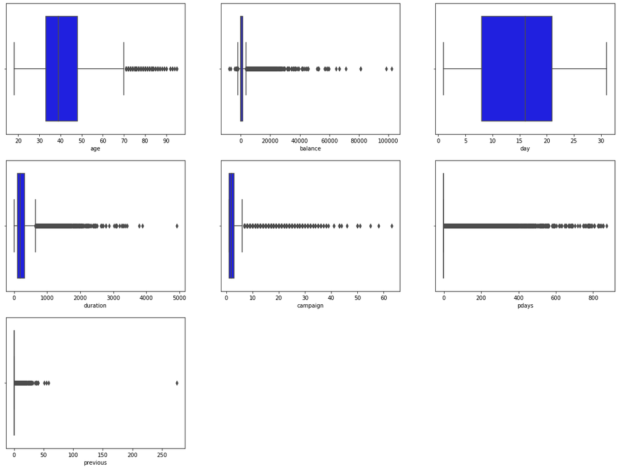

```python
plt.figure(figsize= (20,15))
plt.subplot(3,3,1)
sns.boxplot(x= bank_df.age, color='blue')

plt.subplot(3,3,2)
sns.boxplot(x= bank_df.balance, color='blue')

plt.subplot(3,3,3)
sns.boxplot(x= bank_df.day, color='blue')

plt.subplot(3,3,4)
sns.boxplot(x= bank_df.duration, color='blue')

plt.subplot(3,3,5)
sns.boxplot(x= bank_df.campaign, color='blue')

plt.subplot(3,3,6)
sns.boxplot(x= bank_df.pdays, color='blue')

plt.subplot(3,3,7)
sns.boxplot(x= bank_df.previous, color='blue')
plt.show()
```

# 4. Prepare the data to train a model – check if data types are appropriate, get rid of the missing values etc.

```python
    bank_df.info()  # many columns are of type object i.e. strings. These need to be converted to ordinal type
```

```
<class 'pandas.core.frame.DataFrame'>
RangeIndex: 45211 entries, 0 to 45210
Data columns (total 17 columns):
age          45211 non-null int64
job          45211 non-null object
marital      45211 non-null object
education    45211 non-null object
default      45211 non-null object
balance      45211 non-null int64
housing      45211 non-null object
loan         45211 non-null object
contact      45211 non-null object
day          45211 non-null int64
month        45211 non-null object
duration     45211 non-null int64
campaign     45211 non-null int64
pdays        45211 non-null int64
previous     45211 non-null int64
poutcome     45211 non-null object
Target       45211 non-null object
dtypes: int64(7), object(10)
memory usage: 5.9+ MB
```

### Convert the columns with an 'object' datatype into categorical variables

```python
for feature in bank_df.columns: # Loop through all columns in the dataframe
    if bank_df[feature].dtype == 'object': # Only apply for columns with categorical strings
        bank_df[feature] = pd.Categorical(bank_df[feature])# Replace strings with an integer
bank_df.head(10)
```

|  | age | job | marital | education | default | balance | housing | loan | contact | day | month | duration | campaign | pdays | previous | poutcome | Target |
| --- | --- | --- | --- | --- | --- | --- | --- | --- | --- | --- | --- | --- | --- | --- | --- | --- | --- |
| 0 | 58 | management | married | tertiary | no | 2143 | yes | no | unknown | 5 | may | 261 | 1 | -1 | 0 | unknown | no |
| 1 | 44 | technician | single | secondary | no | 29 | yes | no | unknown | 5 | may | 151 | 1 | -1 | 0 | unknown | no |
| 2 | 33 | entrepreneur | married | secondary | no | 2 | yes | yes | unknown | 5 | may | 76 | 1 | -1 | 0 | unknown | no |
| 3 | 47 | blue-collar | married | unknown | no | 1506 | yes | no | unknown | 5 | may | 92 | 1 | -1 | 0 | unknown | no |
| 4 | 33 | unknown | single | unknown | no | 1 | no | no | unknown | 5 | may | 198 | 1 | -1 | 0 | unknown | no |
| 5 | 35 | management | married | tertiary | no | 231 | yes | no | unknown | 5 | may | 139 | 1 | -1 | 0 | unknown | no |
| 6 | 28 | management | single | tertiary | no | 447 | yes | yes | unknown | 5 | may | 217 | 1 | -1 | 0 | unknown | no |
| 7 | 42 | entrepreneur | divorced | tertiary | yes | 2 | yes | no | unknown | 5 | may | 380 | 1 | -1 | 0 | unknown | no |
| 8 | 58 | retired | married | primary | no | 121 | yes | no | unknown | 5 | may | 50 | 1 | -1 | 0 | unknown | no |
| 9 | 43 | technician | single | secondary | no | 593 | yes | no | unknown | 5 | may | 55 | 1 | -1 | 0 | unknown | no |

```python
print(bank_df.job.value_counts())
print(bank_df.marital.value_counts())
print(bank_df.education.value_counts())
print(bank_df.default.value_counts())
print(bank_df.housing.value_counts())
print(bank_df.loan.value_counts())
print(bank_df.contact.value_counts())
print(bank_df.month.value_counts())
print(bank_df.poutcome.value_counts())
print(bank_df.Target.value_counts())
```

```
blue-collar      9732
management       9458
technician       7597
admin.           5171
services         4154
retired          2264
self-employed    1579
entrepreneur     1487
unemployed       1303
housemaid        1240
student           938
unknown           288
Name: job, dtype: int64
married     27214
single      12790
divorced     5207
Name: marital, dtype: int64
secondary    23202
tertiary     13301
primary       6851
unknown       1857
Name: education, dtype: int64
no     44396
yes      815
Name: default, dtype: int64
yes    25130
no     20081
Name: housing, dtype: int64
no     37967
yes     7244
Name: loan, dtype: int64
cellular     29285
unknown      13020
telephone     2906
Name: contact, dtype: int64
may    13766
jul     6895
aug     6247
jun     5341
nov     3970
apr     2932
feb     2649
jan     1403
oct      738
sep      579
mar      477
dec      214
Name: month, dtype: int64
unknown    36959
failure     4901
other       1840
success     1511
Name: poutcome, dtype: int64
no     39922
yes     5289
Name: Target, dtype: int64
```

```python
replaceStruct = {
                "marital": {"single": 1, "married": 2 ,"divorced": 3},
                "education": {"primary": 1, "secondary": 2 ,"tertiary": 3,"unknown":-1},
                "default": {"no":0, "yes":1},
                "housing": {"no": 0, "yes":1},
                "loan":    {"no": 0, "yes":1},
                "month":   {"jan": 1, "feb": 2, "mar":3, "apr":4, "may":5, "jun":6, "jul":7, "aug":8, "sep":9, "oct":10, "nov":11, "dec":12 },
                "Target":     {"no": 0, "yes": 1 }
                    }
oneHotCols=["job","contact","poutcome"]
```

```python
bank_df=bank_df.replace(replaceStruct)
bank_df=pd.get_dummies(bank_df, columns=oneHotCols)
bank_df.head(10)
```

|  | age | marital | education | default | balance | housing | loan | day | month | duration | ... | job_technician | job_unemployed | job_unknown | contact_cellular | contact_telephone | contact_unknown | poutcome_failure | poutcome_other | poutcome_success | poutcome_unknown |
| --- | --- | --- | --- | --- | --- | --- | --- | --- | --- | --- | --- | --- | --- | --- | --- | --- | --- | --- | --- | --- | --- |
| 0 | 58 | 2 | 3 | 0 | 2143 | 1 | 0 | 5 | 5 | 261 | ... | 0 | 0 | 0 | 0 | 0 | 1 | 0 | 0 | 0 | 1 |
| 1 | 44 | 1 | 2 | 0 | 29 | 1 | 0 | 5 | 5 | 151 | ... | 1 | 0 | 0 | 0 | 0 | 1 | 0 | 0 | 0 | 1 |
| 2 | 33 | 2 | 2 | 0 | 2 | 1 | 1 | 5 | 5 | 76 | ... | 0 | 0 | 0 | 0 | 0 | 1 | 0 | 0 | 0 | 1 |
| 3 | 47 | 2 | -1 | 0 | 1506 | 1 | 0 | 5 | 5 | 92 | ... | 0 | 0 | 0 | 0 | 0 | 1 | 0 | 0 | 0 | 1 |
| 4 | 33 | 1 | -1 | 0 | 1 | 0 | 0 | 5 | 5 | 198 | ... | 0 | 0 | 1 | 0 | 0 | 1 | 0 | 0 | 0 | 1 |
| 5 | 35 | 2 | 3 | 0 | 231 | 1 | 0 | 5 | 5 | 139 | ... | 0 | 0 | 0 | 0 | 0 | 1 | 0 | 0 | 0 | 1 |
| 6 | 28 | 1 | 3 | 0 | 447 | 1 | 1 | 5 | 5 | 217 | ... | 0 | 0 | 0 | 0 | 0 | 1 | 0 | 0 | 0 | 1 |
| 7 | 42 | 3 | 3 | 1 | 2 | 1 | 0 | 5 | 5 | 380 | ... | 0 | 0 | 0 | 0 | 0 | 1 | 0 | 0 | 0 | 1 |
| 8 | 58 | 2 | 1 | 0 | 121 | 1 | 0 | 5 | 5 | 50 | ... | 0 | 0 | 0 | 0 | 0 | 1 | 0 | 0 | 0 | 1 |
| 9 | 43 | 1 | 2 | 0 | 593 | 1 | 0 | 5 | 5 | 55 | ... | 1 | 0 | 0 | 0 | 0 | 1 | 0 | 0 | 0 | 1 |

10 rows × 33 columns

```python
bank_df.info()
```

```
<class 'pandas.core.frame.DataFrame'>
RangeIndex: 45211 entries, 0 to 45210
Data columns (total 33 columns):
age                  45211 non-null int64
marital              45211 non-null int64
education            45211 non-null int64
default              45211 non-null int64
balance              45211 non-null int64
housing              45211 non-null int64
loan                 45211 non-null int64
day                  45211 non-null int64
month                45211 non-null int64
duration             45211 non-null int64
campaign             45211 non-null int64
pdays                45211 non-null int64
previous             45211 non-null int64
Target               45211 non-null int64
job_admin.           45211 non-null uint8
job_blue-collar      45211 non-null uint8
job_entrepreneur     45211 non-null uint8
job_housemaid        45211 non-null uint8
job_management       45211 non-null uint8
job_retired          45211 non-null uint8
job_self-employed    45211 non-null uint8
job_services         45211 non-null uint8
job_student          45211 non-null uint8
job_technician       45211 non-null uint8
job_unemployed       45211 non-null uint8
job_unknown          45211 non-null uint8
contact_cellular     45211 non-null uint8
contact_telephone    45211 non-null uint8
contact_unknown      45211 non-null uint8
poutcome_failure     45211 non-null uint8
poutcome_other       45211 non-null uint8
poutcome_success     45211 non-null uint8
poutcome_unknown     45211 non-null uint8
dtypes: int64(14), uint8(19)
memory usage: 5.6 MB
```

### Split Data

```python
X = bank_df.drop("Target" , axis=1)
y = bank_df.pop("Target")
```

```python
X_train, X_test, y_train, y_test = train_test_split(X, y, test_size=.30, random_state=1)
```

# 5. Train a few standard classification algorithms, note and comment on their performances across different classification metrics

### Logistic regression

Let us first try logistic regression to predict the personal will subscribe a term deposit or not

```python
model = LogisticRegression(solver='liblinear')
model.fit(X_train, y_train)
model_score = model.score(X_test, y_test)
y_predict = model.predict(X_test)
print(model_score)
print(metrics.confusion_matrix(y_test, y_predict))
```

```
0.9002506635210852
[[11712   301]
 [ 1052   499]]
```

```python
print("Classification Report")
print(metrics.classification_report(y_test, y_predict))
```

```
Classification Report
              precision    recall  f1-score   support

           0       0.92      0.97      0.95     12013
           1       0.62      0.32      0.42      1551

    accuracy                           0.90     13564
   macro avg       0.77      0.65      0.68     13564
weighted avg       0.88      0.90      0.89     13564
```

The accuracy score is good with nearly 90%.

But precision and Recall for class 1 is low

### Naive Bayes Model

```python
model = GaussianNB()
model.fit(X_train, y_train)

predictions=model.predict(X_test)
#Assess the accuracy of the model on test data
print("Model Accuracy: {0:.4f}".format(metrics.accuracy_score(y_test, predictions)))
print()
print(metrics.confusion_matrix(y_test,predictions))
```

```
Model Accuracy: 0.8279

[[10404  1609]
 [  725   826]]
```

```python
print(metrics.classification_report(y_test, predictions))
```

```
              precision    recall  f1-score   support

           0       0.93      0.87      0.90     12013
           1       0.34      0.53      0.41      1551

    accuracy                           0.83     13564
   macro avg       0.64      0.70      0.66     13564
weighted avg       0.87      0.83      0.84     13564
```

The accuracy score is gets lower than logistic regression with 82.79%.

The precision and Recall for class 1 is also very low

### K-NN Model

```python
NNH = KNeighborsClassifier(n_neighbors= 5 , weights = 'distance' )
NNH.fit(X_train, y_train)
predicted_labels = NNH.predict(X_test)
print(NNH.score(X_test, y_test))
print(metrics.confusion_matrix(y_test, predicted_labels))
```

```
0.8820406959598939
[[11522   491]
 [ 1109   442]]
```

```python
print(metrics.classification_report(y_test, predicted_labels))
```

```
              precision    recall  f1-score   support

           0       0.91      0.96      0.94     12013
           1       0.47      0.28      0.36      1551

    accuracy                           0.88     13564
   macro avg       0.69      0.62      0.65     13564
weighted avg       0.86      0.88      0.87     13564
```

Recall (true positives / (true positives + false negatives)) for class 1 is the least. That is because majority of data points belong to class 0 and in KNN, probability of finding data points from class 0 closer to a test point than a data point from class 1 is high.

### Build Decision Tree Model

We will build our model using the DecisionTreeClassifier function. Using default 'gini' criteria to split. Other option include 'entropy'

```python
dTree = DecisionTreeClassifier(criterion = 'gini', random_state=1)
dTree.fit(X_train, y_train)
```

```
DecisionTreeClassifier(class_weight=None, criterion='gini', max_depth=None,
                       max_features=None, max_leaf_nodes=None,
                       min_impurity_decrease=0.0, min_impurity_split=None,
                       min_samples_leaf=1, min_samples_split=2,
                       min_weight_fraction_leaf=0.0, presort=False,
                       random_state=1, splitter='best')
```

### Scoring our Decision Tree

```python
print(dTree.score(X_train, y_train))
print(dTree.score(X_test, y_test))
```

```
1.0
0.8717929814214096
```

So the decision is tree model is over fitting the Training data

### Visualizing the Decision Tree

```python
train_char_label = ['No', 'Yes']
bank_Tree_File = open('bank_tree.dot','w')
dot_data = tree.export_graphviz(dTree, out_file=bank_Tree_File, feature_names = list(X_train), class_names = list(train_char_label))
bank_Tree_File.close()
```

```python
#Works only if "dot" command works on you machine
import graphviz
retCode = system("dot -Tpng bank_tree.dot -o bank_tree.png")
if(retCode>0):
    print("system command returning error: "+str(retCode))
else:
    display(Image("bank_tree.png"))
```

[figure not shown]

### Reducing over fitting (Regularization)

```python
dTreeR = DecisionTreeClassifier(criterion = 'gini', max_depth = 3, random_state=1)
dTreeR.fit(X_train, y_train)
print(dTreeR.score(X_train, y_train))
print(dTreeR.score(X_test, y_test))
```

```
0.9005276961481341
0.9019463285166618
```

Limiting the max depth has reduced removed the over fitting and score is also good.

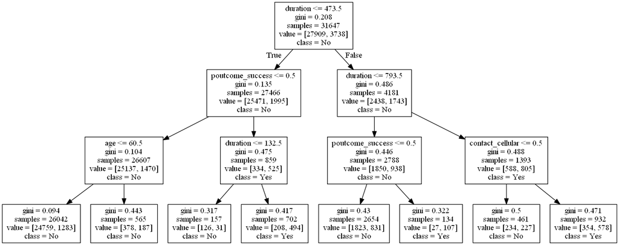

```python
train_char_label = ['No', 'Yes']
bank_Tree_FileR = open('bank_treeR.dot','w')
dot_data = tree.export_graphviz(dTreeR, out_file=bank_Tree_FileR, feature_names = list(X_train), class_names = list(train_char_label))
bank_Tree_FileR.close()

retCode = system("dot -Tpng bank_treeR.dot -o bank_treeR.png")
if(retCode>0):
    print("system command returning error: "+str(retCode))
else:
    display(Image("bank_treeR.png"))
```

```python
y_predictR = dTreeR.predict(X_test)
print(metrics.confusion_matrix(y_test, y_predictR))
```

```
[[11749   264]
 [ 1066   485]]
```

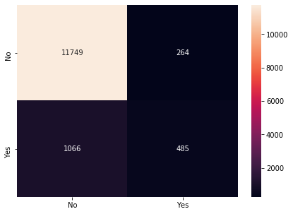

```python
y_predictR = dTreeR.predict(X_test)
cm=metrics.confusion_matrix(y_test, y_predictR, labels=[0, 1])

df_cm = pd.DataFrame(cm, index = [i for i in ["No","Yes"]],
                  columns = [i for i in ["No","Yes"]])
plt.figure(figsize = (7,5))
sns.heatmap(df_cm, annot=True ,fmt='g')
```

```python
print(metrics.classification_report(y_test, y_predictR))
```

```
              precision    recall  f1-score   support

           0       0.92      0.98      0.95     12013
           1       0.65      0.31      0.42      1551

    accuracy                           0.90     13564
   macro avg       0.78      0.65      0.68     13564
weighted avg       0.89      0.90      0.89     13564
```

Preceision and recall still for class 1 still low

# 6. Build the ensemble models and compare the results with the base models. Note: Random forest can be used only with Decision trees.

### Ensemble Learning - Bagging

```python
bgcl = BaggingClassifier(base_estimator=dTree, n_estimators=50,random_state=1)
bgcl = bgcl.fit(X_train, y_train)
```

```
0.9071807726334414
```

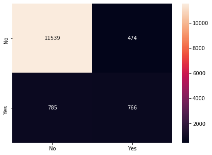

```python
y_predict = bgcl.predict(X_test)

print(bgcl.score(X_test , y_test))

cm=metrics.confusion_matrix(y_test, y_predict,labels=[0, 1])

df_cm = pd.DataFrame(cm, index = [i for i in ["No","Yes"]],
                  columns = [i for i in ["No","Yes"]])
plt.figure(figsize = (7,5))
sns.heatmap(df_cm, annot=True ,fmt='g')
```

### Ensemble Learning - AdaBoost

```python
#abcl = AdaBoostClassifier(base_estimator=dTree, n_estimators=10)
abcl = AdaBoostClassifier( n_estimators=50)
abcl = abcl.fit(X_train, y_train)
```

In contrary to Bagging for boosting the principle is that we should take simple base model. Now if we take dTree as base estimator which it self is very complex as we see above the Performance decrease to nearly 87.2% Now if we allow AsaBoostClassifier to select default base_estimator ot select some very simple Model and performance increse to 90.04%

```
0.9004718372161604
```

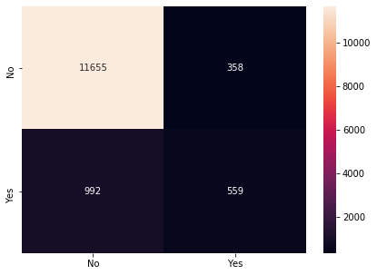

```python
y_predict = abcl.predict(X_test)
print(abcl.score(X_test, y_test))
cm=metrics.confusion_matrix(y_test, y_predict,labels=[0, 1])

df_cm = pd.DataFrame(cm, index = [i for i in ["No","Yes"]],
                  columns = [i for i in ["No","Yes"]])
plt.figure(figsize = (7,5))
sns.heatmap(df_cm, annot=True ,fmt='g')
```

### Ensemble Learning - GradientBoost

```python
gbcl = GradientBoostingClassifier(n_estimators = 50,random_state=1)
gbcl = gbcl.fit(X_train, y_train)
```

```
0.9026835741669124
```

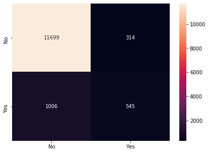

```python
y_predict = gbcl.predict(X_test)
print(gbcl.score(X_test, y_test))
cm=metrics.confusion_matrix(y_test, y_predict,labels=[0, 1])

df_cm = pd.DataFrame(cm, index = [i for i in ["No","Yes"]],
                  columns = [i for i in ["No","Yes"]])
plt.figure(figsize = (7,5))
sns.heatmap(df_cm, annot=True ,fmt='g')
```

### Ensemble Learning- RandomForest Classifier

```python
rfcl = RandomForestClassifier(n_estimators = 50, random_state=1,max_features=10)
rfcl = rfcl.fit(X_train, y_train)
```

Random Forest classier is essentially follows the Bagging principle and use starts with Complex base model. The max_feature is very important for otimizing the performace of the model. there are nearly 33 columns so by default the value should be near about square root of 33 i.e 6. But varying the value from 6 to 12 we find 10 gives the best performance.

```
0.9072544971984665
```

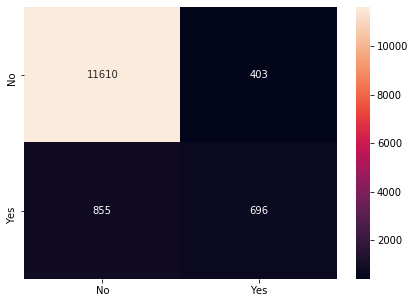

```python
y_predict = rfcl.predict(X_test)
print(rfcl.score(X_test, y_test))
cm=metrics.confusion_matrix(y_test, y_predict,labels=[0, 1])

df_cm = pd.DataFrame(cm, index = [i for i in ["No","Yes"]],
                  columns = [i for i in ["No","Yes"]])
plt.figure(figsize = (7,5))
sns.heatmap(df_cm, annot=True ,fmt='g')
```

# 7. Compare performances of all the models

Logistic regression 90.02%

Naive Bayes Model 82.79%

K-NN Model 88.20%

Decision Tree Model after regularization give quite good performance as overfitting is almost removed with a score 90.19%

Applying Ensembling techniques

Bagging 90.718%

AdaBoost 90.04%

Gradient Boost 90.268%

Random Forest Classifier 90.725%